# k-means

Source : http://www.statmethods.net/advstats/cluster.html

Data Preparation Prior to clustering data, you may want to remove or estimate missing data and rescale variables for comparability.

```r
mydata <- na.omit(mtcars)
#mydata <- scale(mydata[,1:4]) # standardize variables
head(mydata)
```

|  | mpg | cyl | disp | hp | drat | wt | qsec | vs | am | gear | carb |
| --- | --- | --- | --- | --- | --- | --- | --- | --- | --- | --- | --- |
| Mazda RX4 | 21.0 | 6 | 160 | 110 | 3.90 | 2.620 | 16.46 | 0 | 1 | 4 | 4 |
| Mazda RX4 Wag | 21.0 | 6 | 160 | 110 | 3.90 | 2.875 | 17.02 | 0 | 1 | 4 | 4 |
| Datsun 710 | 22.8 | 4 | 108 | 93 | 3.85 | 2.320 | 18.61 | 1 | 1 | 4 | 1 |
| Hornet 4 Drive | 21.4 | 6 | 258 | 110 | 3.08 | 3.215 | 19.44 | 1 | 0 | 3 | 1 |
| Hornet Sportabout | 18.7 | 8 | 360 | 175 | 3.15 | 3.440 | 17.02 | 0 | 0 | 3 | 2 |
| Valiant | 18.1 | 6 | 225 | 105 | 2.76 | 3.460 | 20.22 | 1 | 0 | 3 | 1 |

```r
tail(mydata)
```

|  | mpg | cyl | disp | hp | drat | wt | qsec | vs | am | gear | carb |
| --- | --- | --- | --- | --- | --- | --- | --- | --- | --- | --- | --- |
| Porsche 914-2 | 26.0 | 4 | 120.3 | 91 | 4.43 | 2.140 | 16.7 | 0 | 1 | 5 | 2 |
| Lotus Europa | 30.4 | 4 | 95.1 | 113 | 3.77 | 1.513 | 16.9 | 1 | 1 | 5 | 2 |
| Ford Pantera L | 15.8 | 8 | 351.0 | 264 | 4.22 | 3.170 | 14.5 | 0 | 1 | 5 | 4 |
| Ferrari Dino | 19.7 | 6 | 145.0 | 175 | 3.62 | 2.770 | 15.5 | 0 | 1 | 5 | 6 |
| Maserati Bora | 15.0 | 8 | 301.0 | 335 | 3.54 | 3.570 | 14.6 | 0 | 1 | 5 | 8 |
| Volvo 142E | 21.4 | 4 | 121.0 | 109 | 4.11 | 2.780 | 18.6 | 1 | 1 | 4 | 2 |

```r
summary(mydata)
```

```
      mpg             cyl             disp             hp             drat             wt             qsec             vs               am              gear            carb
 Min.   :10.40   Min.   :4.000   Min.   : 71.1   Min.   : 52.0   Min.   :2.760   Min.   :1.513   Min.   :14.50   Min.   :0.0000   Min.   :0.0000   Min.   :3.000   Min.   :1.000
 1st Qu.:15.43   1st Qu.:4.000   1st Qu.:120.8   1st Qu.: 96.5   1st Qu.:3.080   1st Qu.:2.581   1st Qu.:16.89   1st Qu.:0.0000   1st Qu.:0.0000   1st Qu.:3.000   1st Qu.:2.000
 Median :19.20   Median :6.000   Median :196.3   Median :123.0   Median :3.695   Median :3.325   Median :17.71   Median :0.0000   Median :0.0000   Median :4.000   Median :2.000
 Mean   :20.09   Mean   :6.188   Mean   :230.7   Mean   :146.7   Mean   :3.597   Mean   :3.217   Mean   :17.85   Mean   :0.4375   Mean   :0.4062   Mean   :3.688   Mean   :2.812
 3rd Qu.:22.80   3rd Qu.:8.000   3rd Qu.:326.0   3rd Qu.:180.0   3rd Qu.:3.920   3rd Qu.:3.610   3rd Qu.:18.90   3rd Qu.:1.0000   3rd Qu.:1.0000   3rd Qu.:4.000   3rd Qu.:4.000
 Max.   :33.90   Max.   :8.000   Max.   :472.0   Max.   :335.0   Max.   :4.930   Max.   :5.424   Max.   :22.90   Max.   :1.0000   Max.   :1.0000   Max.   :5.000   Max.   :8.000
```

```r
str(mydata)
```

```
'data.frame':   32 obs. of  11 variables:
 $ mpg : num  21 21 22.8 21.4 18.7 18.1 14.3 24.4 22.8 19.2 ...
 $ cyl : num  6 6 4 6 8 6 8 4 4 6 ...
 $ disp: num  160 160 108 258 360 ...
 $ hp  : num  110 110 93 110 175 105 245 62 95 123 ...
 $ drat: num  3.9 3.9 3.85 3.08 3.15 2.76 3.21 3.69 3.92 3.92 ...
 $ wt  : num  2.62 2.88 2.32 3.21 3.44 ...
 $ qsec: num  16.5 17 18.6 19.4 17 ...
 $ vs  : num  0 0 1 1 0 1 0 1 1 1 ...
 $ am  : num  1 1 1 0 0 0 0 0 0 0 ...
 $ gear: num  4 4 4 3 3 3 3 4 4 4 ...
 $ carb: num  4 4 1 1 2 1 4 2 2 4 ...
```

Partitioning K-means clustering is the most popular partitioning method. It requires the analyst to specify the number of clusters to extract. A plot of the within groups sum of squares by number of clusters extracted can help determine the appropriate number of clusters. The analyst looks for a bend in the plot similar to a scree test in factor analysis. See Everitt & Hothorn (pg. 251).

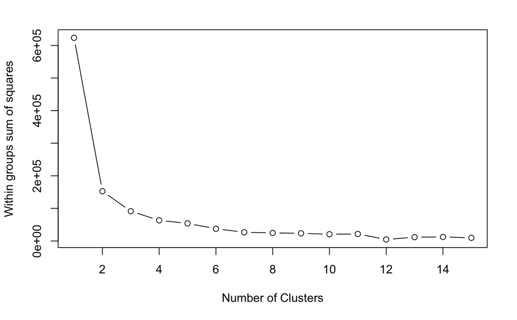

```r
wss <- (nrow(mydata)-1)*sum(apply(mydata,2,var))
for (i in 2:15) wss[i] <- sum(kmeans(mydata,
    centers=i)$withinss)
plot(1:15, wss, type="b", xlab="Number of Clusters",
  ylab="Within groups sum of squares")
```

```r
# K-Means Cluster Analysis
fit <- kmeans(mydata, 5) # 5 cluster solution
# get cluster means
aggregate(mydata,by=list(fit$cluster),FUN=mean)
```

| Group.1 | mpg | cyl | disp | hp | drat | wt | qsec | vs | am | gear | carb |
| --- | --- | --- | --- | --- | --- | --- | --- | --- | --- | --- | --- |
| 1 | 31.00000 | 4.000000 | 76.1250 | 62.2500 | 4.327500 | 1.896250 | 19.19750 | 1.0000000 | 1.0000000 | 4.000000 | 1.250000 |
| 2 | 22.33333 | 4.833333 | 137.6833 | 108.4167 | 3.894167 | 2.725250 | 18.32500 | 0.6666667 | 0.5833333 | 4.166667 | 2.833333 |
| 3 | 14.68000 | 8.000000 | 426.4000 | 200.0000 | 3.078000 | 4.660800 | 17.45800 | 0.0000000 | 0.0000000 | 3.000000 | 3.200000 |
| 4 | 14.60000 | 8.000000 | 340.5000 | 272.2500 | 3.675000 | 3.537500 | 15.08750 | 0.0000000 | 0.5000000 | 4.000000 | 5.000000 |
| 5 | 17.01429 | 7.428571 | 276.0571 | 150.7143 | 2.994286 | 3.601429 | 18.11857 | 0.2857143 | 0.0000000 | 3.000000 | 2.142857 |

```r
# append cluster assignment
mydata <- data.frame(mydata, fit$cluster)
```

A robust version of K-means based on mediods can be invoked by using pam( ) instead of kmeans( ). The function pamk( ) in the fpc package is a wrapper for pam that also prints the suggested number of clusters based on optimum average silhouette width.

Hierarchical Agglomerative There are a wide range of hierarchical clustering approaches. I have had good luck with Ward’s method described below.

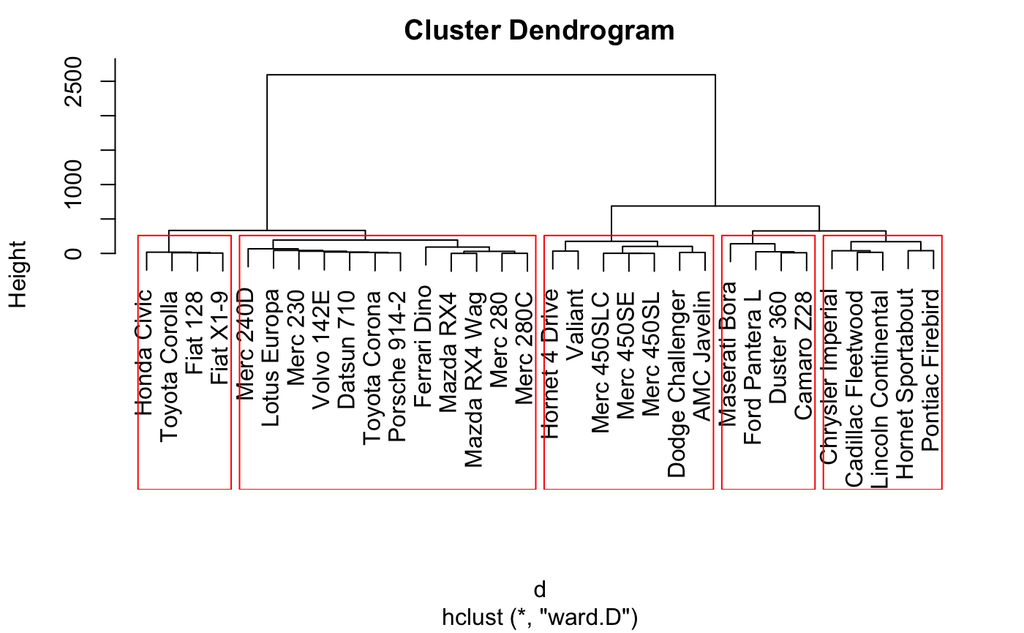

```r
# Ward Hierarchical Clustering
d <- dist(mydata, method = "euclidean") # distance matrix
fit <- hclust(d, method="ward.D")
plot(fit) # display dendogram
groups <- cutree(fit, k=5) # cut tree into 5 clusters
# draw dendogram with red borders around the 5 clusters
rect.hclust(fit, k=5, border="red")
```

The pvclust( ) function in the pvclust package provides p-values for hierarchical clustering based on multiscale bootstrap resampling. Clusters that are highly supported by the data will have large p values. Interpretation details are provided Suzuki. Be aware that pvclust clusters columns, not rows. Transpose your data before using.

```r
# Ward Hierarchical Clustering with Bootstrapped p values
library(pvclust)
fit <- pvclust(mydata, method.hclust="ward.D",
   method.dist="euclidean")
```

```
Bootstrap (r = 0.5)... Done.
Bootstrap (r = 0.59)... Done.
Bootstrap (r = 0.69)... Done.
Bootstrap (r = 0.78)... Done.
Bootstrap (r = 0.88)... Done.
Bootstrap (r = 1.0)... Done.
Bootstrap (r = 1.09)... Done.
Bootstrap (r = 1.19)... Done.
Bootstrap (r = 1.28)... Done.
Bootstrap (r = 1.38)... Done.
```

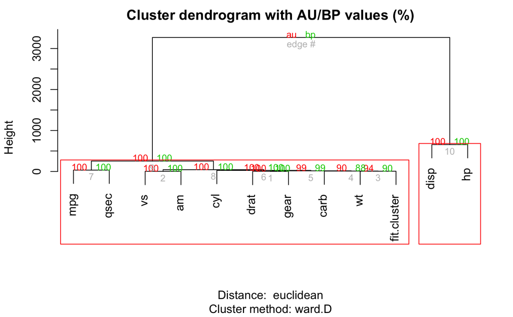

```r
plot(fit) # dendogram with p values
# add rectangles around groups highly supported by the data
pvrect(fit, alpha=.95)
```

Model Based Model based approaches assume a variety of data models and apply maximum likelihood estimation and Bayes criteria to identify the most likely model and number of clusters. Specifically, the Mclust( ) function in the mclust package selects the optimal model according to BIC for EM initialized by hierarchical clustering for parameterized Gaussian mixture models. (phew!). One chooses the model and number of clusters with the largest BIC. See help(mclustModelNames) to details on the model chosen as best.

```r
# Model Based Clustering
library(mclust)
fit <- Mclust(mydata)
plot(fit) # plot results
```

```
Model-based clustering plots:

1: BIC
2: classification
3: uncertainty
4: density
```

```r
1
```

```
Model-based clustering plots:

1: BIC
2: classification
3: uncertainty
4: density
```

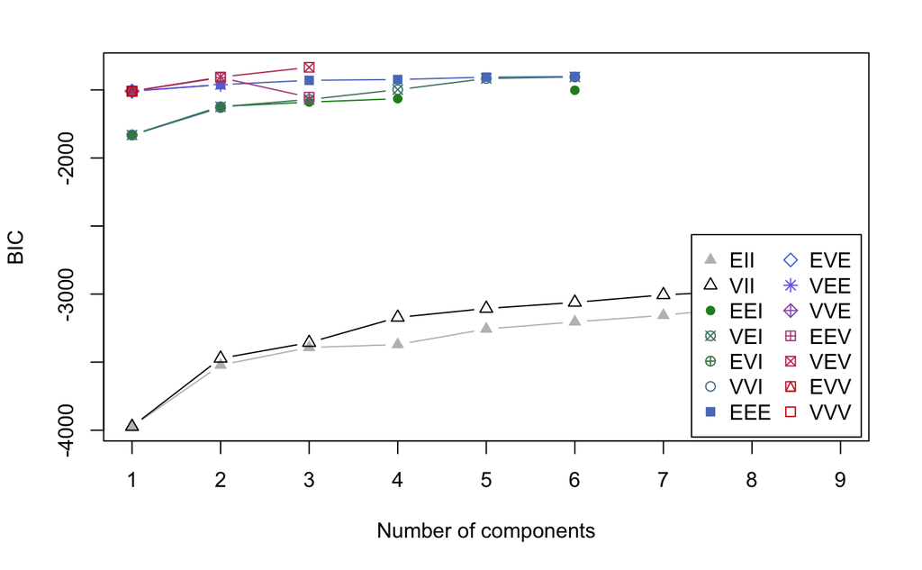

```r
0
```

```r
summary(fit) # display the best model
```

```
----------------------------------------------------
Gaussian finite mixture model fitted by EM algorithm
----------------------------------------------------

Mclust VEV (ellipsoidal, equal shape) model with 3 components:

 log.likelihood  n  df       BIC       ICL
       -233.859 32 250 -1334.152 -1334.152

Clustering table:
 1  2  3
16  7  9
```

Plotting Cluster Solutions It is always a good idea to look at the cluster results.

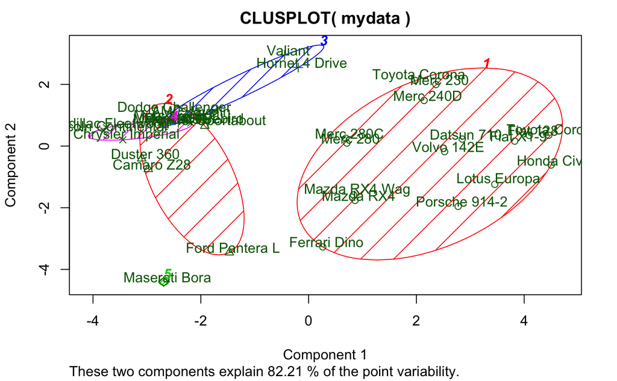

```r
# K-Means Clustering with 5 clusters
fit <- kmeans(mydata, 5)
# Cluster Plot against 1st 2 principal components
# vary parameters for most readable graph
library(cluster)
clusplot(mydata, fit$cluster, color=TRUE, shade=TRUE,
    labels=2, lines=0)
```

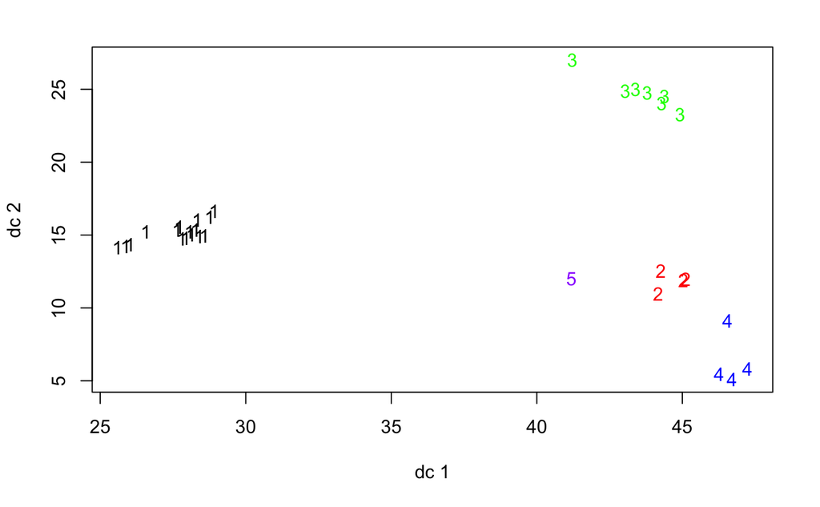

```r
# Centroid Plot against 1st 2 discriminant functions
library(fpc)
plotcluster(mydata, fit$cluster)
```

Validating cluster solutions The function cluster.stats() in the fpc package provides a mechanism for comparing the similarity of two cluster solutions using a variety of validation criteria (Hubert’s gamma coefficient, the Dunn index and the corrected rand index).

```r
# comparing 2 cluster solutions
library(fpc)
# cluster.stats(d, fit1$cluster, fit2$cluster)
cluster.stats(d, fit$cluster, fit$cluster)
```

```
$n
[1] 32

$cluster.number
[1] 5

$cluster.size
[1] 16  4  7  4  1

$min.cluster.size
[1] 1

$noisen
[1] 0

$diameter
[1] 141.70798  89.59899 103.43107  78.53853        NA

$average.distance
[1] 58.05842 46.90951 54.71369 50.21171      NaN

$median.distance
[1] 54.90006 45.72472 51.82425 54.52152       NA

$separation
[1] 60.34019 40.00525 49.02470 40.00525 86.93833

$average.toother
[1] 245.0924 204.2239 162.3816 260.4867 236.7570

$separation.matrix
          [,1]      [,2]      [,3]      [,4]      [,5]
[1,]   0.00000 199.33700  60.34019 238.17471 223.54316
[2,] 199.33700   0.00000  49.02470  40.00525  86.93833
[3,]  60.34019  49.02470   0.00000  85.83082 157.16651
[4,] 238.17471  40.00525  85.83082   0.00000 174.29656
[5,] 223.54316  86.93833 157.16651 174.29656   0.00000

$ave.between.matrix
         [,1]     [,2]     [,3]     [,4]     [,5]
```

[output cut: 57 more lines]

```

$cwidegap
[1] 56.83651 70.18385 61.36019 68.20307  0.00000

$widestgap
[1] 70.18385

$sindex
[1] 43.01173

$corrected.rand
[1] 1

$vi
[1] 0
```

where d is a distance matrix among objects, and fit1$cluster and fit$cluster are integer vectors containing classification results from two different clusterings of the same data.